# Applying clustering methods to Boston data set

## Bonus

Here I am fitting lda model with k-means clusters as a target variable. The bi-plot again shows separation of our three k-clusters in two distict groups. `indus`, `nox`, `tax` and `rad` seem to pull the two groups apart, that means that Boston suburbs could be separated by proportion of industries located in the area, pollution level, full-value property-tax rate and accessibility of highways. Crime level doesn’t seem to be at play.

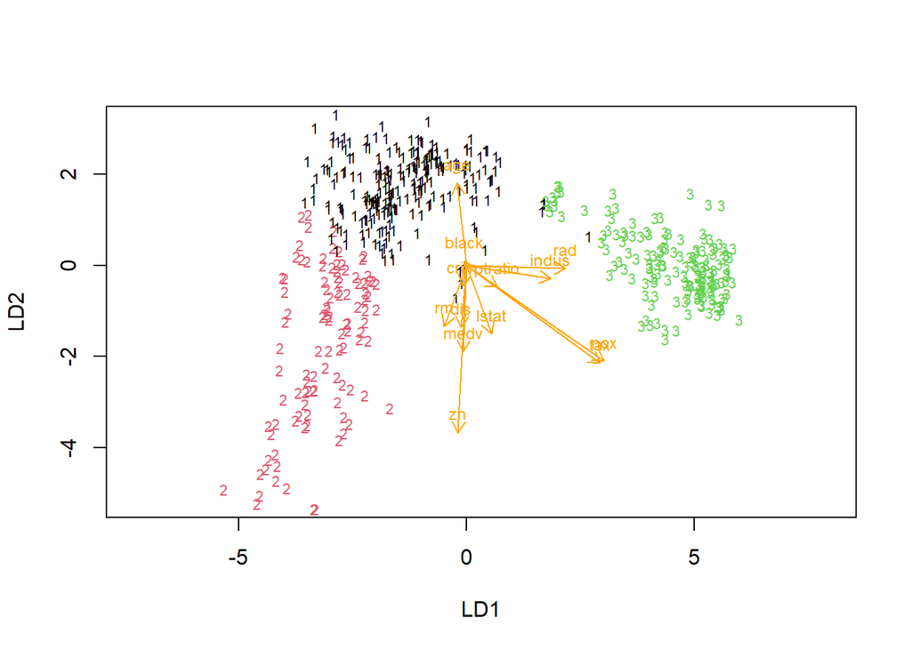

```r
# reloading data
data("Boston")

# scaling
boston_scale <- scale(Boston)
boston_scale <- as.data.frame(boston_scale)

# somehow knitting doesn't work with this varible
boston_scale <- dplyr::select(boston_scale, -chas)

# running K-means algorithm
km <-kmeans(boston_scale, centers = 3)

# adding new clusters as target variable
clusters <- as.factor(km$cluster)

boston_scale <- mutate(boston_scale, clusters = clusters)

# running LDA
lda.fit2 <- lda(clusters ~ ., data = boston_scale)

# plotting the lda results
class <- as.numeric(boston_scale$clusters)

plot(lda.fit2, dimen = 2, col = class, pch = class)
lda.arrows(lda.fit2, myscale = 3)
```